Griffin Shelor  
28-2-2024

# In-class Exercises: Numpy Part 1

```python
import numpy as np
import matplotlib.pyplot as plt
```

### Q1. Create two `numpy` `arrays`, both of length 8. One array should be all zeros, the second should be all ones.

```python
array1 = np.zeros(8)
array2 = np.ones(8)
```

### Q2. Create a `numpy` `array` with values from 2 through 12 in steps of one, e.g. `[2,3,4,...,11,12]`. Make this `dtype = int`.

```python
array3 = np.arange(2,13, 1, dtype= 'int')
print(array3, array3.dtype)
```

```
[ 2  3  4  5  6  7  8  9 10 11 12] int64
```

### Q3. Create a `numpy` `array` of 361 values equally spaced between 0 and 2$\pi$. Name this array `x`.

```python
x = np.linspace(0, (2 * np.pi), 361)
print(x)
```

[output not shown]

### Q4. Calculate `y1=np.cos(x)` and `y2=np.sin(x)`, where `x` is the array you created above. Plot `x` vs `y`, with `x` on the x-axis and `y1` and `y2` on the y-axis. Add a legend to plot.

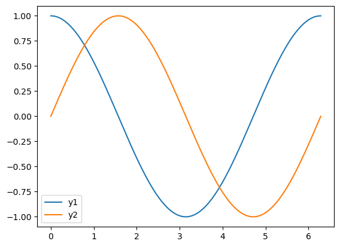

```python
y1 = np.cos(x)
y2 = np.sin(x)
plt.plot(x, y1, label = 'y1')
plt.plot(x, y2, label = 'y2')
plt.legend(loc= 'best');
```

### Q5. Create an array named `q5arr` with 10 equally spaced integers with the first value 5 and the last value 50. Use slicing to view two new arrays, one with the first 5 values named `q5arr1` and one with the last 5 values named `q5arr2`. Print both of these slices.

```python
q5arr = np.linspace(5,50,10)
q5arr1 = q5arr[0:5]
print(q5arr1)
q5arr2 = q5arr[5:]
print(q5arr2)
```

```
[ 5. 10. 15. 20. 25.]
[30. 35. 40. 45. 50.]
```

### Q6. `Reshape` the array `q5arr` to 5x2 and print it, then `reshape` to 2x5 and print again.

```python
q6arr1 = q5arr.reshape(5,2)
print(q6arr1)
q6arr2 = q5arr.reshape(2,5)
print(q6arr2)
```

```
[[ 5. 10.]
 [15. 20.]
 [25. 30.]
 [35. 40.]
 [45. 50.]]
[[ 5. 10. 15. 20. 25.]
 [30. 35. 40. 45. 50.]]
```

```python
q7arr1 = q5arr1 + q5arr2
q7arr2 = q5arr1 * q5arr2
print(q7arr1, q7arr2)
```

```
[35. 45. 55. 65. 75.] [ 150.  350.  600.  900. 1250.]
```

### Q8. Make an array that `concatenates` `q7arr1` and `q7arr2`

```python
q8arr1 = np.concatenate((q7arr1, q7arr2))
print(q8arr1)
```

```
[  35.   45.   55.   65.   75.  150.  350.  600.  900. 1250.]
```

### Q9. Use logical (boolean) indexing to print the names of the male ducks from Disney movies. Use the data in the cell below, which includes the names, studios (Disney or Warner) and gender identity of 7 classic cartoon characters.

```python
# Use this input data.
names = np.array(["Donald", "Daisy", "Huey", "Dewey",
                  "Louie", "Daffy", "Daphne"])
studios = np.array(['Disney', 'Disney', 'Disney', 'Disney',
                     'Disney', 'Warner', 'Warner'])
genders = np.array(['male', 'female', 'male', 'male',
                    'male', 'male', 'female'])
```

```python
print(names[(genders == 'male') & (studios == 'Disney')])
```

```
['Donald' 'Huey' 'Dewey' 'Louie']
```

### Save your notebook and output an html version. To receive credit for this in-class exercise upload both the .html and .ipynb files.